# Activity Monitor Data

SatyaBharat

July 25, 2017

## Activity Monitor Data Assignment

Loading and preprocessing the data

1. What is mean total number of steps taken per day? Now make a histogram of the number of steps per day. Here we will ignore any missing values.

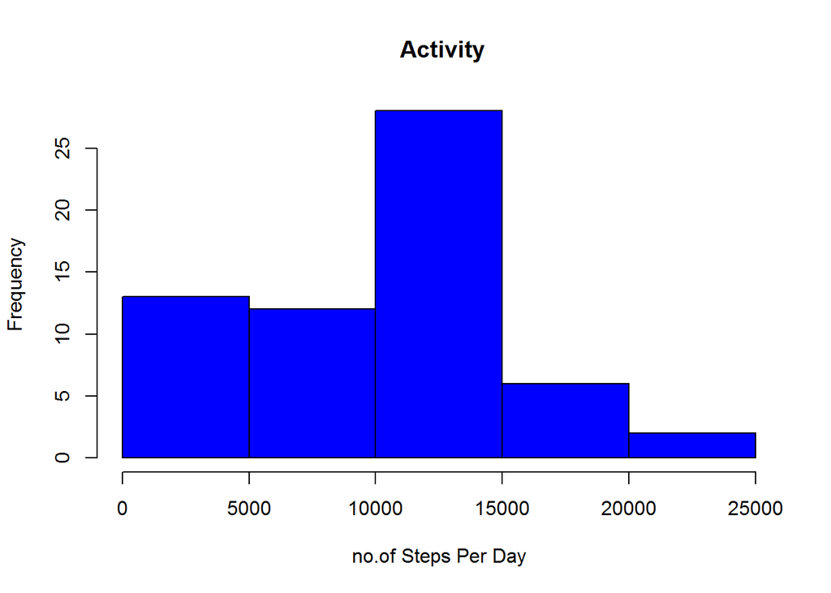

```r
monitor.daily <- ddply(monitor, .(date.factor), summarize,
                        total.steps=sum(steps, na.rm=TRUE))
hist(monitor.daily$total.steps, col="blue", main=" Activity",
     xlab="no.of Steps Per Day")
```

2.Mean and Median per day

```r
pdaymean <- mean(monitor.daily$total.steps, na.rm=TRUE)
pdaymedian <- median(monitor.daily$total.steps, na.rm=TRUE)
cat(paste("The mean number of steps per day is",
          format(pdaymean, digits=4), "and the median is",
          format(pdaymedian, digits=2), "(ignoring missing values"))
```

```
## The mean number of steps per day is 9354 and the median is 10395 (ignoring missing values
```

3. What is the average daily monitor pattern?

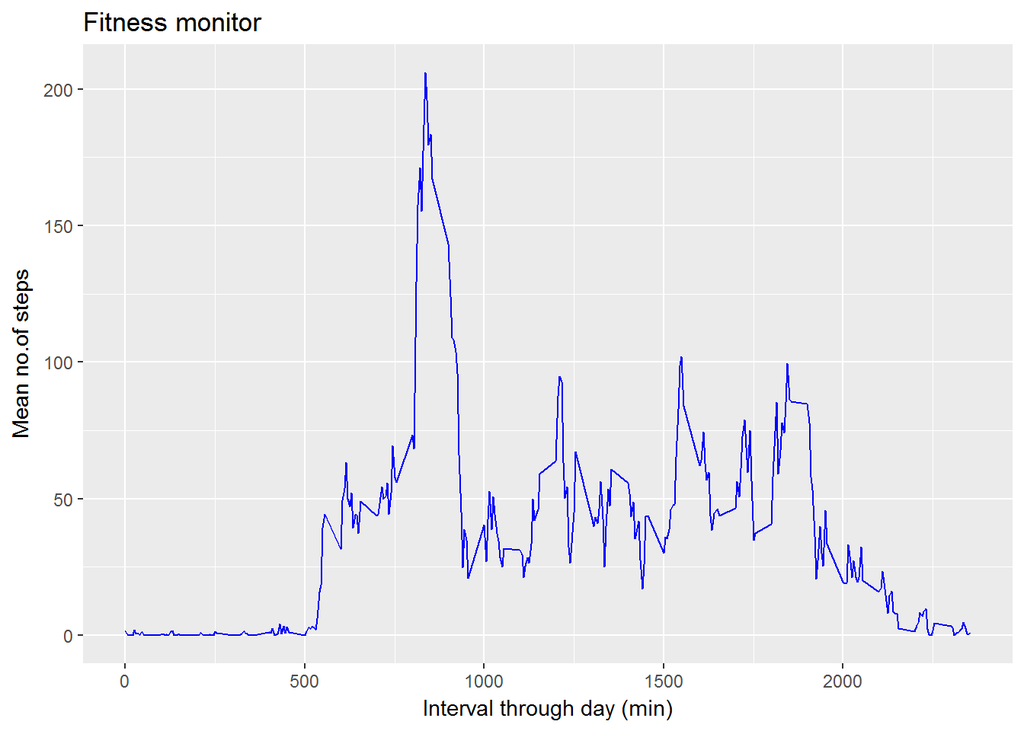

```r
monitor.pattern <- ddply(monitor, "interval", summarize,
                          mean=mean(steps, na.rm=TRUE))
g <- ggplot(monitor.pattern, aes(interval, mean))
g + geom_line(color="blue") +
  labs(title="Fitness monitor",
       x="Interval through day (min)",
       y="Mean no.of steps")
```

4. What interval has the highest average number of steps?

```r
max.interval <- monitor.pattern$interval[which.max(monitor.pattern$mean)]
cat(paste("Interval corresponding to maximum average number of steps:",
          max.interval,"minutes"))
```

```
## Interval corresponding to maximum average number of steps: 835 minutes
```

5. Imputing missing values

```
## Number of rows with missing data: 2304
```

We fill missing values for the number of steps with the mean number for that interval. Note that this will make the steps non-integral.

```r
impute.value <- function(steps, interval) {
    if (is.na(steps)) {
        monitor.pattern[monitor.pattern$interval==interval,]$mean
    } else {
        steps
    }
}
imputed.monitor <- monitor
imputed.monitor$steps <- mapply(impute.value, monitor$steps,
                                monitor$interval)
```

Now see how different the mean and median are for the total number per day with and without imputation:

```r
total.steps <- tapply(monitor$steps, monitor$date.factor,
                      sum, na.rm=TRUE)
total.steps.imputed <- tapply(imputed.monitor$steps,
                              imputed.monitor$date.factor, sum)
cat(paste("For the raw data the mean and median per day are:",
          format(mean(total.steps)), "and", median(total.steps)))
```

```
## For the raw data the mean and median per day are: 9354.23 and 10395
```

```r
cat(paste("For the imputed the mean and median per day are:",
          format(mean(total.steps.imputed)), "and",
          format(median(total.steps.imputed))))
```

```
## For the imputed the mean and median per day are: 10766.19 and 10766.19
```

Make a histogram of the mean number per day after imputation.

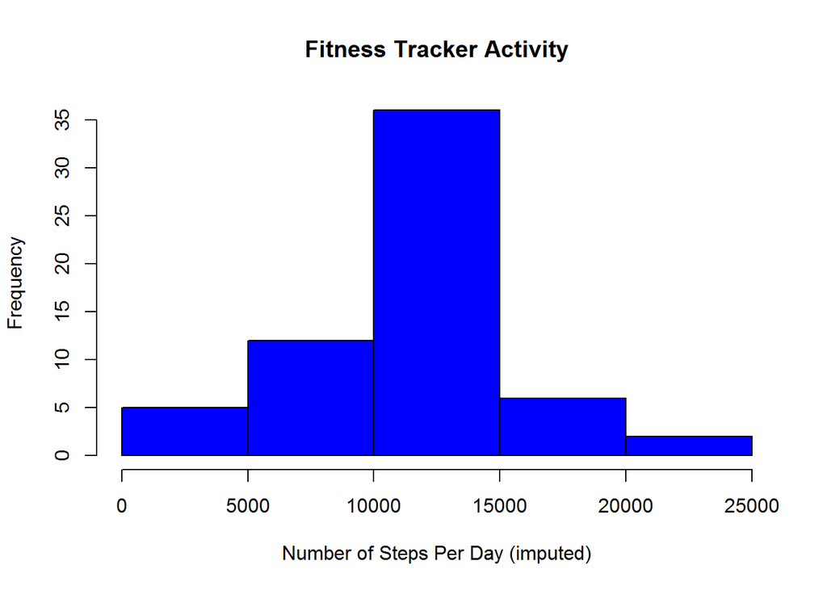

```r
hist(total.steps.imputed, col="blue", main="Fitness Tracker Activity",
     xlab="Number of Steps Per Day (imputed)")
```

Check to make sure we filled in all the missing values:

```r
nmissing <- sum(!complete.cases(imputed.monitor))
cat(paste("After imputation, number of rows with missing data:", nmissing))
```

```
## After imputation, number of rows with missing data: 0
```

Are there differences in monitor patterns between weekdays and weekends?

Add a factor variable for weekday vs. weekend:

```r
daytype <- function(date)
    if (weekdays(date) %in% c("Saturday", "Sunday")) "weekend" else "weekday"
imputed.monitor$day.type <- as.factor(sapply(imputed.monitor$date, daytype))
```

And look at the mean number of steps per day per date type:

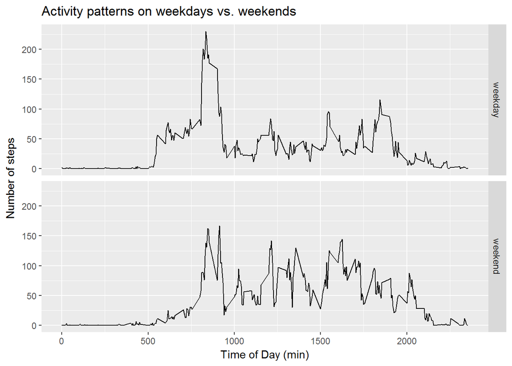

```r
steps.day.daytype <- ddply(imputed.monitor, .(interval, day.type),
                           summarize, steps=mean(steps))
ggplot(steps.day.daytype, aes(interval, steps)) +
    geom_line() + facet_grid(day.type ~ .) +
    labs(x="Time of Day (min)", y="Number of steps",
         title="Activity patterns on weekdays vs. weekends")
```